# Module–Trait Association — Motor Cortex (Bulk RNA-seq)

Extended Analysis: Age, FTD/AD Comorbidity, Site of Motor Onset

ALS Deconvolution Project

2026-04-28

> **What this analysis adds:** Extends the original Motor Cortex WGCNA module–trait correlation (ALS, Sex, RIN, C9ORF72) with three new trait categories:
> - **Age at Death** — tests for age-driven transcriptional changes that might confound ALS associations.
> - **FTD/AD Comorbidity** — binary indicator (1 if `Subject.Group.Subcategory` contains Frontotemporal Dementia or Alzheimer’s Disease).
> - **Site of Motor Onset** — three dummy columns:
>   - **Onset_Limb**: all limb/extremity variants, combined entries (e.g., “Bulbar and Limb”), and Generalized.
>   - **Onset_Bulbar**: Bulbar, combined entries, and Generalized.
>   - **Onset_Axial**: Axial, combined entries, and Generalized.

**Dataset:** Motor Cortex — Bulk RNA-seq | **Retained samples:** 320 | **Non-grey modules:** 52

# 1 Metadata Encoding

Summary of new trait encoding

| Category | Full cohort (n) | Retained in WGCNA (n) |
| --- | --- | --- |
| FTD/AD (= 1) | 64 | 48 |
| FTD/AD absent (= 0) | 432 | 272 |
| Onset: Limb | 297 | 188 |
| Onset: Bulbar | 126 | 86 |
| Onset: Axial | 24 | 19 |
| Age: available | 488 | 313 |

# 2 Full Module–Trait Heatmap

All 52 non-grey modules × 9 traits.

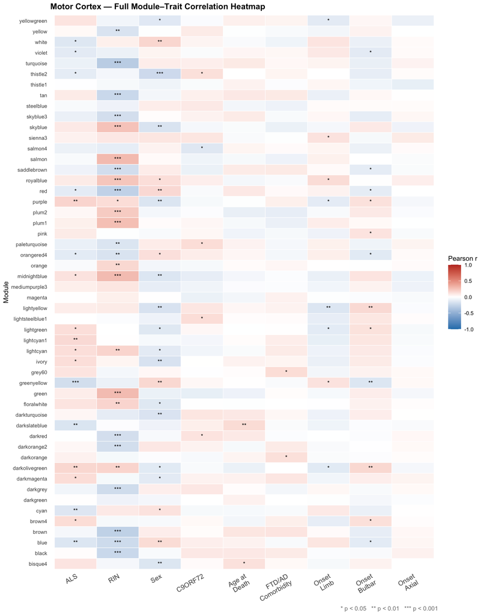

# 3 Filtered Modules: ALS p < 0.05 and RIN p > 0.05

**11 module(s) passed the filter:**

Filtered modules: ALS-significant and RIN-independent

| Module | r (ALS) | p (ALS) | r (RIN) | p (RIN) | r (Age) | p (Age) | r (FTD/AD) | p (FTD/AD) | Direction |
| --- | --- | --- | --- | --- | --- | --- | --- | --- | --- |
| thistle2 | -0.110 | 0.048700 | -0.049 | 0.378 | -0.002 | 0.97500 | 0.043 | 0.4470 | DOWN in ALS ↓ |
| darkmagenta | 0.138 | 0.013300 | -0.040 | 0.474 | 0.055 | 0.32500 | 0.100 | 0.0741 | UP in ALS ↑ |
| brown4 | 0.141 | 0.011800 | -0.036 | 0.517 | -0.055 | 0.32800 | 0.068 | 0.2270 | UP in ALS ↑ |
| lightcyan1 | 0.153 | 0.005970 | 0.006 | 0.916 | 0.012 | 0.83200 | 0.072 | 0.2000 | UP in ALS ↑ |
| lightgreen | 0.134 | 0.016100 | -0.003 | 0.964 | -0.004 | 0.94800 | 0.004 | 0.9400 | UP in ALS ↑ |
| ivory | 0.134 | 0.016600 | 0.041 | 0.465 | 0.051 | 0.36600 | 0.041 | 0.4660 | UP in ALS ↑ |
| darkslateblue | -0.158 | 0.004600 | -0.013 | 0.813 | 0.145 | 0.00937 | -0.023 | 0.6860 | DOWN in ALS ↓ |
| greenyellow | -0.196 | 0.000421 | -0.083 | 0.140 | 0.006 | 0.91000 | -0.029 | 0.6110 | DOWN in ALS ↓ |
| white | -0.142 | 0.011200 | 0.064 | 0.257 | -0.029 | 0.60500 | -0.067 | 0.2310 | DOWN in ALS ↓ |
| cyan | -0.145 | 0.009210 | 0.084 | 0.132 | -0.035 | 0.53200 | -0.030 | 0.5910 | DOWN in ALS ↓ |
| violet | -0.123 | 0.027600 | -0.082 | 0.141 | 0.039 | 0.48400 | 0.032 | 0.5630 | DOWN in ALS ↓ |

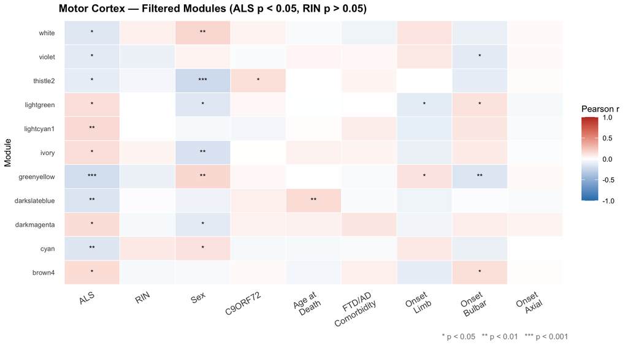

# 4 ALS Association Direction — Bar Graph

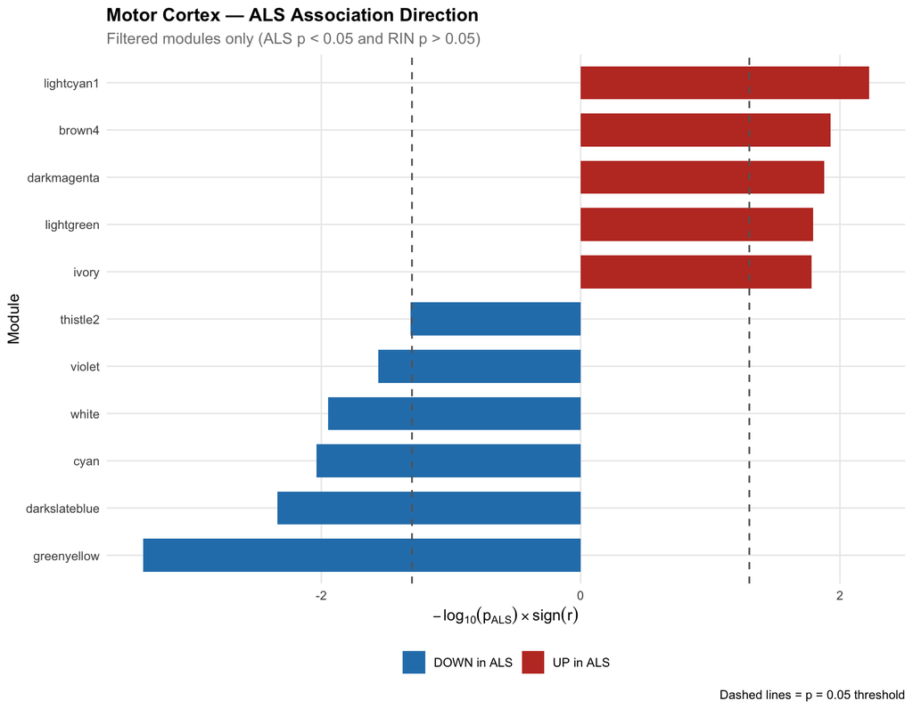

# 5 Summary & Brief Analysis

**11 module(s)** survived the dual filter: **5 up-regulated** and **6 down-regulated** in ALS.

- The Motor Cortex contains samples from lateral *and* medial sub-regions, which may introduce within-tissue heterogeneity. Modules passing the RIN filter are less likely to reflect tissue-quality differences between sub-regions.
- Correlation with Site of Motor Onset (Limb vs Bulbar) may reflect differential involvement of primary motor cortex regions in distinct ALS subtypes.
- FTD/AD comorbidity associations could highlight shared or distinct neurodegeneration pathways between ALS and frontotemporal/Alzheimer’s pathology in the motor cortex.

*Generated by `MC_Subset_Analysis.Rmd` | WGCNA module structure from existing bulk Motor Cortex network | Extended trait matrix: ALS, RIN, Sex, C9ORF72, Age, FTD/AD, Onset (Limb/Bulbar/Axial)*